# Report

NN

4/7/2022

## Data Set

This data set contains the purchase history over an one month period in an online platfrom for 239 article categories. This study will help us to understand the business product that has a very good response over internet selling. 5 top selling products over this online platform are

| article_cat | mon_sales |
| --- | --- |
| pants | 419885 |
| shirts | 363677 |
| underpants | 278266 |
| bras | 189509 |
| nightgown/pajamas | 176958 |

## Best Article Category

To show the best article categories we will draw some figure. To do that we first calculate the the top category which are consistently rank on top 3 with respect to sell quantity. Then from those category that we select for each day we find out the top selling article name for selected categpry each day.

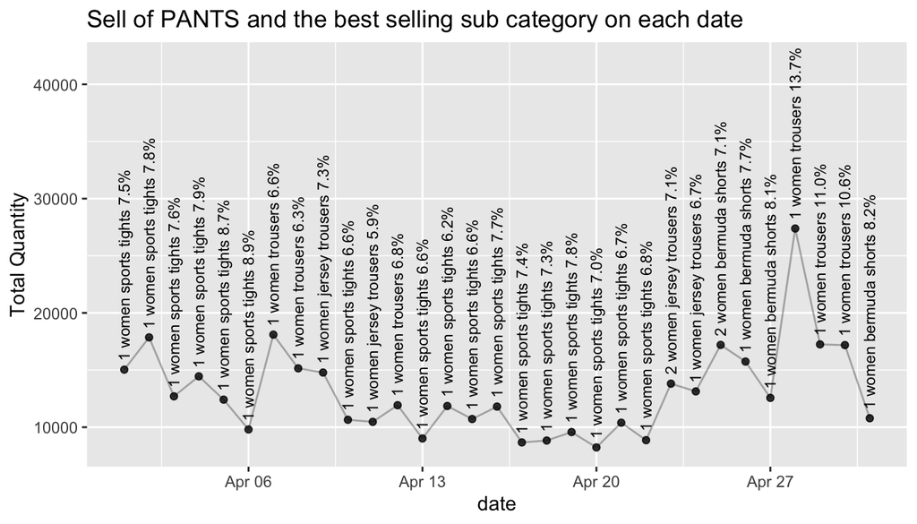

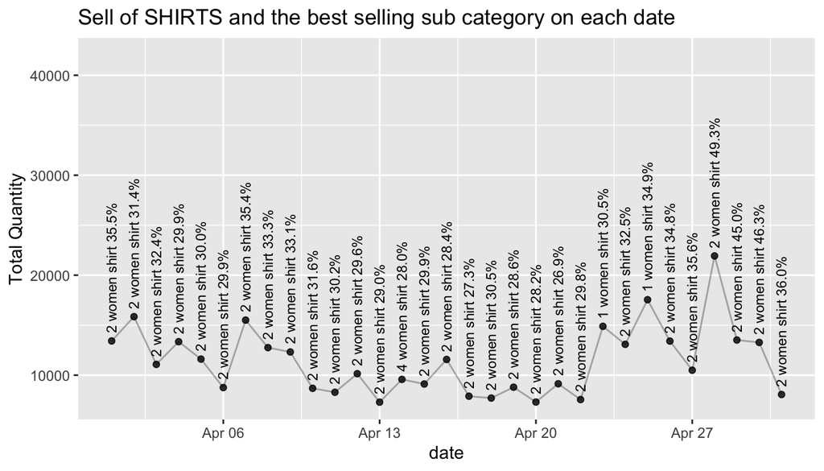

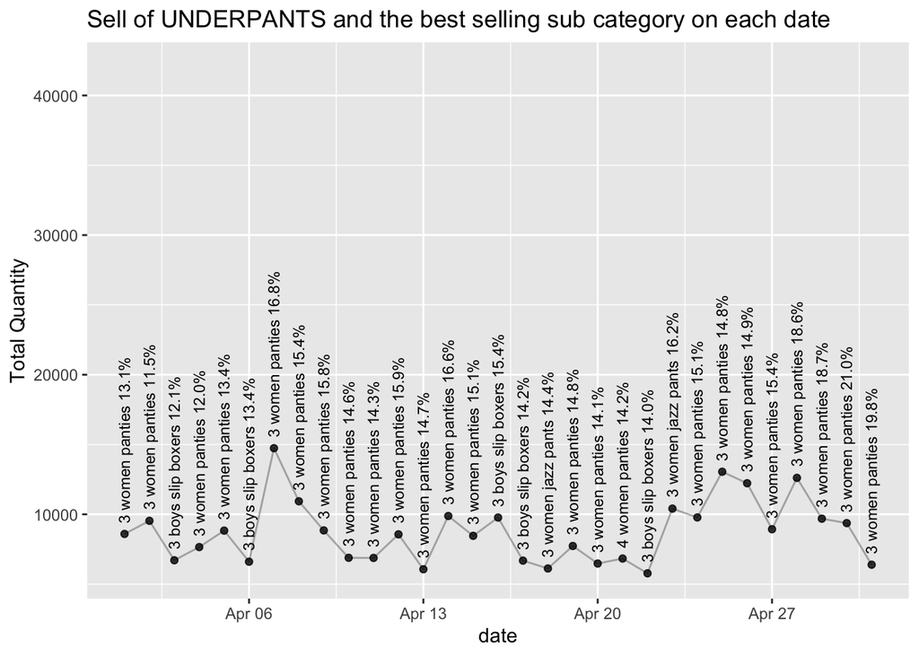

## Business Inside

So from those graph we can see some pattern. For example there is a huge amount of sell at 7 and 28 april compare to other day. May be some discount of flash sell happend that day. Also what we can say that on average female do more shopping than male. As pant and the shirt are the most popular products category and female products are dominating on those categories so it is advised to expand the product variety for female on those two categories. It is astonashing that the Under Pants is the top 3 most popular category. So companies can provide their attention to improve and expand the variety of those products.